# Homework 6

James Kolesar

5/2/2020

# 9

```r
library(glmnet)
library(pls)
library(readxl)
College <- read_excel("College.xlsx")
```

```
## * `` -> ...1
```

## (a)

```r
length(College$Apps)
```

```
## [1] 777
```

```r
set.seed(1)
training.numbers = sample(777,583)
College.training = College[training.numbers,]
College.test = College[-training.numbers,]
```

## (b)

```r
College.least.squares.training = lm(Apps ~ Private + Accept + Enroll + Top10perc + Top25perc + F.Undergrad + P.Undergrad + Outstate + Room.Board + Books + Personal + PhD + Terminal + S.F.Ratio + perc.alumni + Expend + Grad.Rate, data = College.training)

mean((College$Apps-predict(College.least.squares.training, College))[-training.numbers]^2)
```

```
## [1] 1153318
```

Least squares left us with a test error of 1,153,318

## (c)

```r
x.training = model.matrix(Apps ~ Private + Accept + Enroll + Top10perc + Top25perc + F.Undergrad + P.Undergrad + Outstate + Room.Board + Books + Personal + PhD + Terminal + S.F.Ratio + perc.alumni + Expend + Grad.Rate, College.training)[,-1]

y.training = College.training$Apps

x.test = model.matrix(Apps ~ Private + Accept + Enroll + Top10perc + Top25perc + F.Undergrad + P.Undergrad + Outstate + Room.Board + Books + Personal + PhD + Terminal + S.F.Ratio + perc.alumni + Expend + Grad.Rate, College.test)[,-1]

y.test = College.test$Apps

grid = 10^seq(10, -2, length = 100)

College.ridge.training.mod = glmnet(x.training, y.training, alpha = 0, lambda = grid, thresh=1e-12)
```

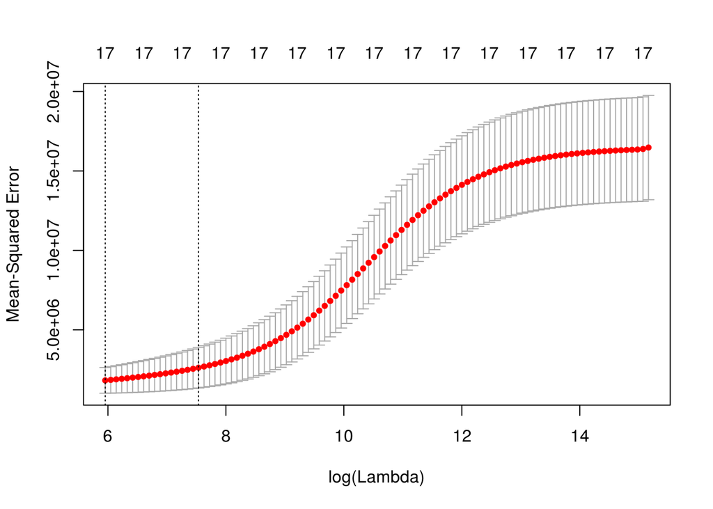

```r
cv.out = cv.glmnet(x.training, y.training, alpha=0)

plot(cv.out)
```

```r
bestlam = cv.out$lambda.min

bestlam
```

```
## [1] 385.4793
```

```r
College.ridge.pred = predict(College.ridge.training.mod, s = bestlam, newx = x.test)

mean((College.ridge.pred-y.test)^2)
```

```
## [1] 1130697
```

Ridge Regression left us with a test error of 1,130,697

## (d)

```r
College.lasso = glmnet(x.training, y.training, alpha = 1, lambda = grid)
```

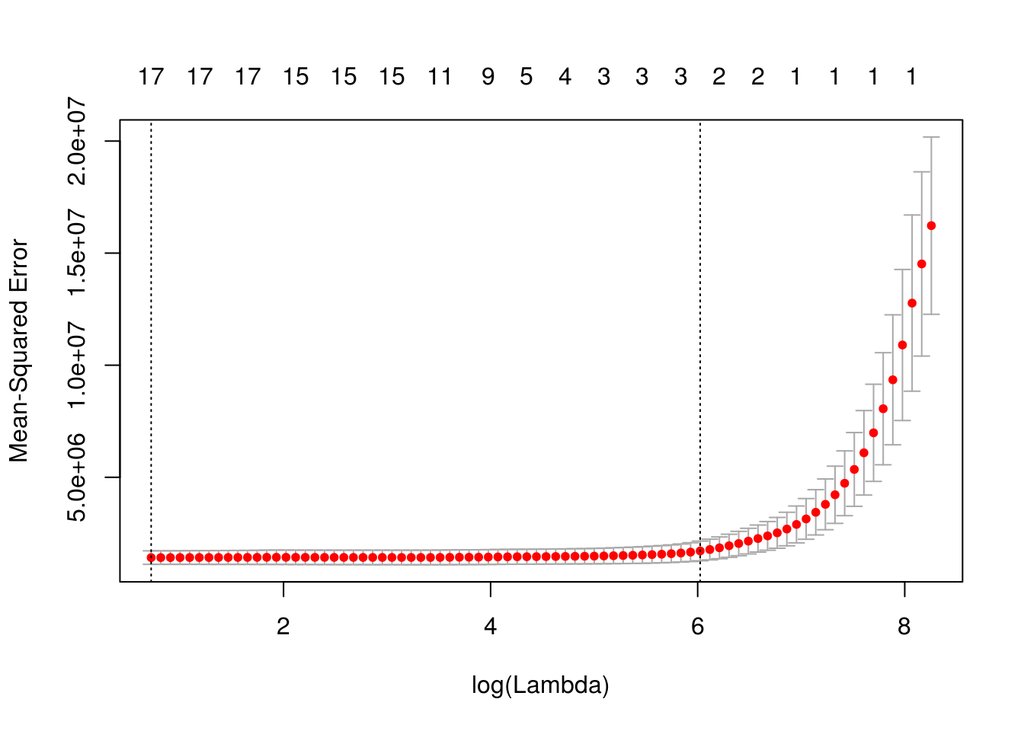

```r
cv.out = cv.glmnet(x.training, y.training, alpha = 1)
plot(cv.out)
```

```r
bestlam = cv.out$lambda.min
bestlam
```

```
## [1] 2.057187
```

```r
College.lasso.pred = predict(College.lasso, s = bestlam, newx = x.test)
mean((College.lasso.pred - y.test)^2)
```

```
## [1] 1148500
```

Lasso left us with a test error of 1,148,500

## (e)

```r
College.pcr = pcr(Apps ~ Private + Accept + Enroll + Top10perc + Top25perc + F.Undergrad + P.Undergrad + Outstate + Room.Board + Books + Personal + PhD + Terminal + S.F.Ratio + perc.alumni + Expend + Grad.Rate, data = College.training, scale = TRUE, validation = "CV")

summary(College.pcr)
```

```
## Data:    X dimension: 583 17
##  Y dimension: 583 1
## Fit method: svdpc
## Number of components considered: 17
##
## VALIDATION: RMSEP
## Cross-validated using 10 random segments.
##        (Intercept)  1 comps  2 comps  3 comps  4 comps  5 comps  6 comps
## CV            4062     4070     2184     2162     2132     1719     1694
## adjCV         4062     4076     2182     2162     2171     1708     1688
##        7 comps  8 comps  9 comps  10 comps  11 comps  12 comps  13 comps
## CV        1689     1693     1586      1596      1602      1607      1612
## adjCV     1684     1688     1581      1591      1597      1603      1607
##        14 comps  15 comps  16 comps  17 comps
## CV         1617      1544      1186      1167
## adjCV      1614      1524      1178      1159
##
## TRAINING: % variance explained
##       1 comps  2 comps  3 comps  4 comps  5 comps  6 comps  7 comps  8 comps
## X      31.082    57.80    64.51    70.29    75.84    80.85    84.36    87.70
## Apps    1.466    71.95    72.46    72.49    83.79    83.97    84.08    84.08
##       9 comps  10 comps  11 comps  12 comps  13 comps  14 comps  15 comps
## X       90.56     92.96     95.03     96.85     97.96     98.74     99.37
## Apps    85.92     86.00     86.04     86.05     86.07     86.20     91.01
##       16 comps  17 comps
## X        99.84    100.00
## Apps     93.35     93.63
```

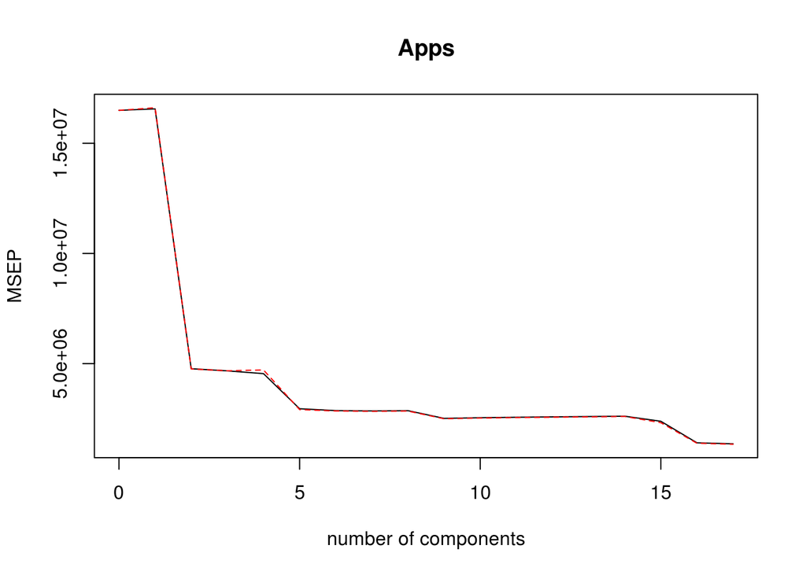

```r
validationplot(College.pcr, val.type = "MSEP")
```

Note that I’m assuming here that when the homework asks to choose M based on cross validation that we should choose whatever M that minimizes validation error. I was going to use 18, but it errored out when I tried to knit, so 17 will do.

```r
pcr.pred = predict(College.pcr, x.test, ncomp = 17)

mean((pcr.pred-y.test)^2)
```

```
## [1] 1153318
```

PCR left us with a test error of 1,153,318

## (f)

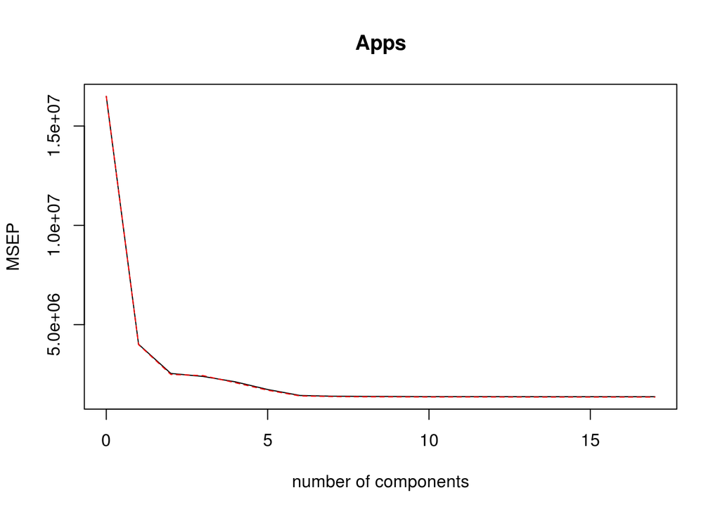

```r
College.pls = plsr(Apps ~ Private + Accept + Enroll + Top10perc + Top25perc + F.Undergrad + P.Undergrad + Outstate + Room.Board + Books + Personal + PhD + Terminal + S.F.Ratio + perc.alumni + Expend + Grad.Rate, data = College.training, scale = TRUE, validation = "CV")

validationplot(College.pls, val.type = "MSEP")
```

```r
pls.pred = predict(College.pls, x.test, ncomp = 8)

mean((pls.pred-y.test)^2)
```

```
## [1] 1148675
```

PLS left us with a test error of 1,148,675

## (g)

Well it looks like the number of college applicants is pretty tough to predict using the other variables in our college data set, with test error ranging around 1.1-1.2 million. We should take this with a grain of salt, since the variable we were using was so high itself, but even taking that into account the error was still not promising at all. Despite this, our observations still showed us that there wasn’t too much to gain by using our more complex modeling techniques. Since the error is about the same, the simplest model (least squares) becomes my personal model of choice. The lack of chance with models might have to do with our lack of relevant predictors in our model, as seen by our massive error. Almost… too massive. I mean, we are working with a variable ranging through the thousands, but 1.2 million? At that point is it even worth trying to predict? Something feels weird.

```r
summary(College$Apps)
```

```
##    Min. 1st Qu.  Median    Mean 3rd Qu.    Max.
##      81     776    1558    3002    3624   48094
```

Something feels… a bit off.

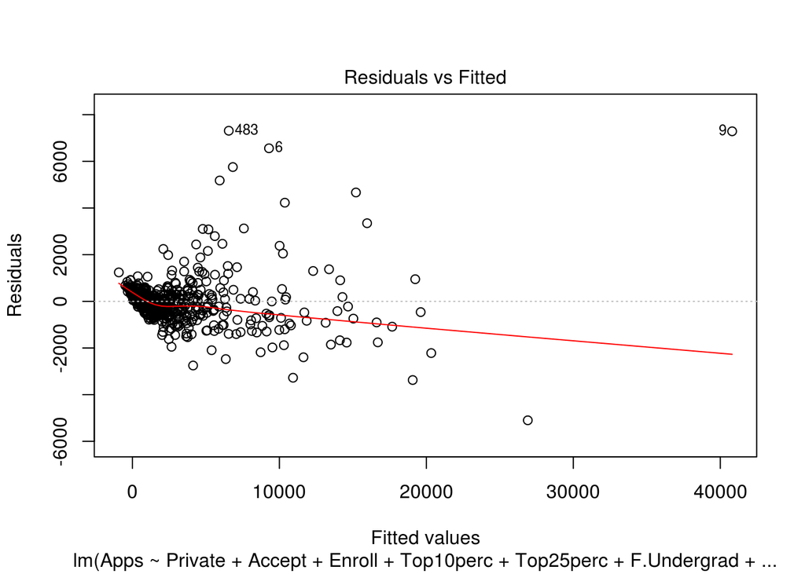

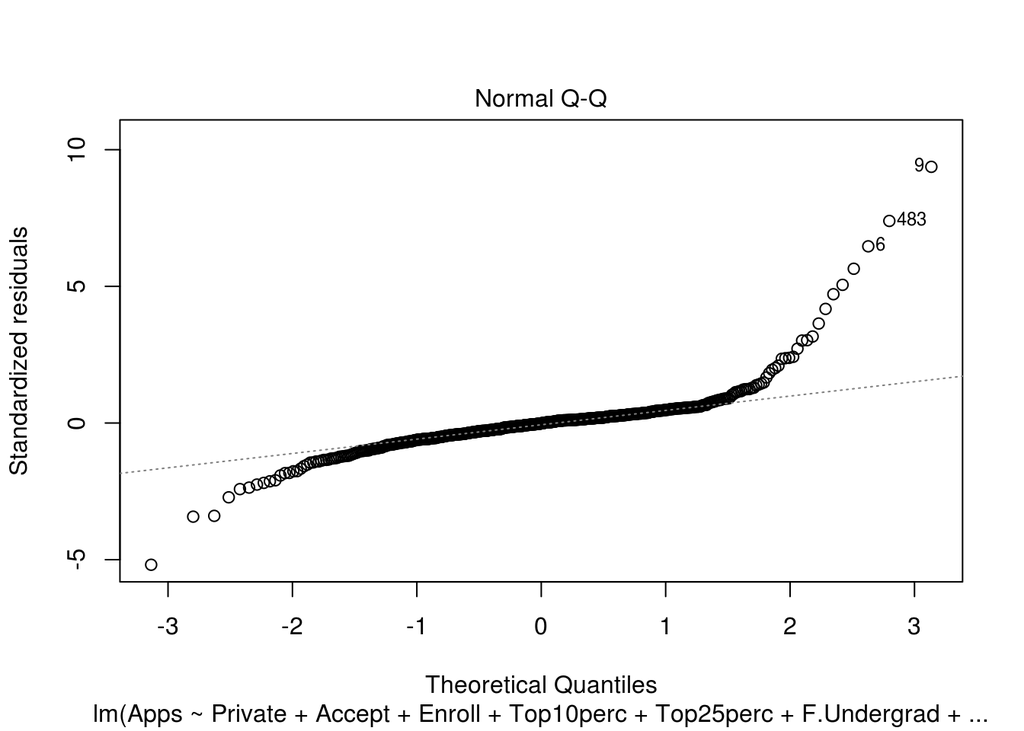

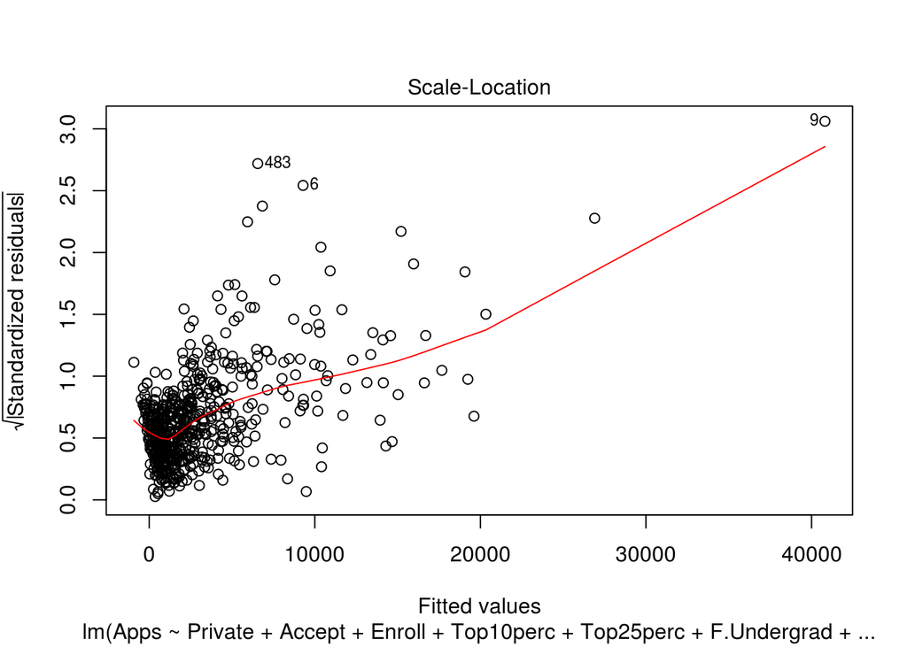

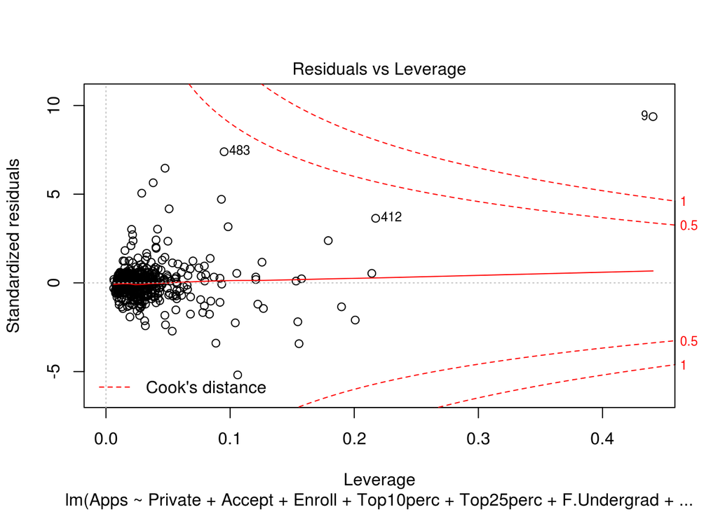

```r
plot(College.least.squares.training)
```

A bit off indeed. Our test error is totally thrown off thanks to Rutgers at New Brunswick’s absolutely ridiculous effect on our data. I’m interested to see if removing this unruly outlier does anything to our test error, let’s run through these models one more time.

```r
New.College = College[-484,]
summary(New.College$Apps)
```

```
##    Min. 1st Qu.  Median    Mean 3rd Qu.    Max.
##      81     776    1558    2944    3603   21804
```

## (New.a)

```r
length(New.College$Apps)
```

```
## [1] 776
```

```r
set.seed(1)
training.numbers = sample(776,582)
New.College.training = New.College[training.numbers,]
New.College.test = New.College[-training.numbers,]
```

## (New.b)

```r
New.College.least.squares.training = lm(Apps ~ Private + Accept + Enroll + Top10perc + Top25perc + F.Undergrad + P.Undergrad + Outstate + Room.Board + Books + Personal + PhD + Terminal + S.F.Ratio + perc.alumni + Expend + Grad.Rate, data = New.College.training)

mean((New.College$Apps-predict(New.College.least.squares.training, New.College))[-training.numbers]^2)
```

```
## [1] 934377.2
```

## (New.c)

```r
New.x.training = model.matrix(Apps ~ Private + Accept + Enroll + Top10perc + Top25perc + F.Undergrad + P.Undergrad + Outstate + Room.Board + Books + Personal + PhD + Terminal + S.F.Ratio + perc.alumni + Expend + Grad.Rate, New.College.training)[,-1]

New.y.training = New.College.training$Apps

New.x.test = model.matrix(Apps ~ Private + Accept + Enroll + Top10perc + Top25perc + F.Undergrad + P.Undergrad + Outstate + Room.Board + Books + Personal + PhD + Terminal + S.F.Ratio + perc.alumni + Expend + Grad.Rate, New.College.test)[,-1]

New.y.test = New.College.test$Apps

grid = 10^seq(10, -2, length = 100)

New.College.ridge.training.mod = glmnet(New.x.training, New.y.training, alpha = 0, lambda = grid, thresh = 1e-12)
```

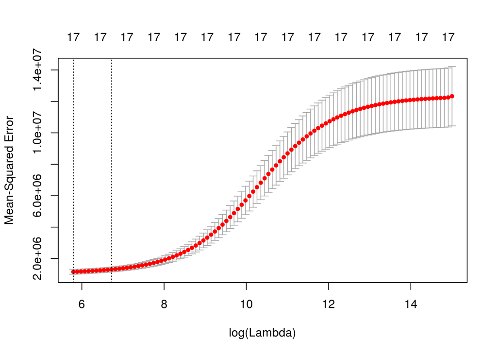

```r
cv.out = cv.glmnet(New.x.training, New.y.training, alpha = 0)

plot(cv.out)
```

```r
bestlam = cv.out$lambda.min

bestlam
```

```
## [1] 328.1185
```

```r
New.College.ridge.pred = predict(New.College.ridge.training.mod, s = bestlam, newx = New.x.test)

mean((New.College.ridge.pred - New.y.test)^2)
```

```
## [1] 1159361
```

## (New.d)

```r
New.College.lasso = glmnet(New.x.training, New.y.training, alpha = 1, lambda=grid)
```

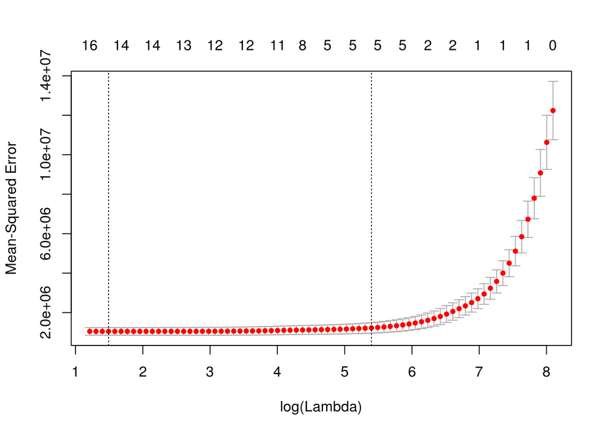

```r
set.seed(1)
cv.out = cv.glmnet(New.x.training, New.y.training, alpha = 1)
plot(cv.out)
```

```r
bestlam = cv.out$lambda.min
bestlam
```

```
## [1] 4.439599
```

```r
New.College.lasso.pred = predict(New.College.lasso, s = bestlam, newx = New.x.test)
mean((New.College.lasso.pred - New.y.test)^2)
```

```
## [1] 936335
```

## (New.e)

```r
New.College.pcr = pcr(Apps ~ Private + Accept + Enroll + Top10perc + Top25perc + F.Undergrad + P.Undergrad + Outstate + Room.Board + Books + Personal + PhD + Terminal + S.F.Ratio + perc.alumni + Expend + Grad.Rate, data = New.College.training, scale = TRUE, validation = "CV")

summary(New.College.pcr)
```

```
## Data:    X dimension: 582 17
##  Y dimension: 582 1
## Fit method: svdpc
## Number of components considered: 17
##
## VALIDATION: RMSEP
## Cross-validated using 10 random segments.
##        (Intercept)  1 comps  2 comps  3 comps  4 comps  5 comps  6 comps
## CV            3511     3485     1687     1691     1533     1314     1279
## adjCV         3511     3486     1686     1691     1549     1297     1277
##        7 comps  8 comps  9 comps  10 comps  11 comps  12 comps  13 comps
## CV        1262     1261     1161      1154      1158      1162      1169
## adjCV     1258     1261     1157      1152      1156      1160      1166
##        14 comps  15 comps  16 comps  17 comps
## CV         1168      1173      1046      1043
## adjCV      1166      1171      1043      1039
##
## TRAINING: % variance explained
##       1 comps  2 comps  3 comps  4 comps  5 comps  6 comps  7 comps  8 comps
## X      31.578    57.81    64.45    70.21    75.64    80.69    84.22    87.47
## Apps    1.799    77.30    77.59    81.92    87.29    87.44    87.82    87.84
##       9 comps  10 comps  11 comps  12 comps  13 comps  14 comps  15 comps
## X       90.41     92.84     94.96     96.81     97.93     98.86     99.42
## Apps    89.65     89.75     89.75     89.76     89.76     89.77     89.96
##       16 comps  17 comps
## X        99.85     100.0
## Apps     92.14      92.3
```

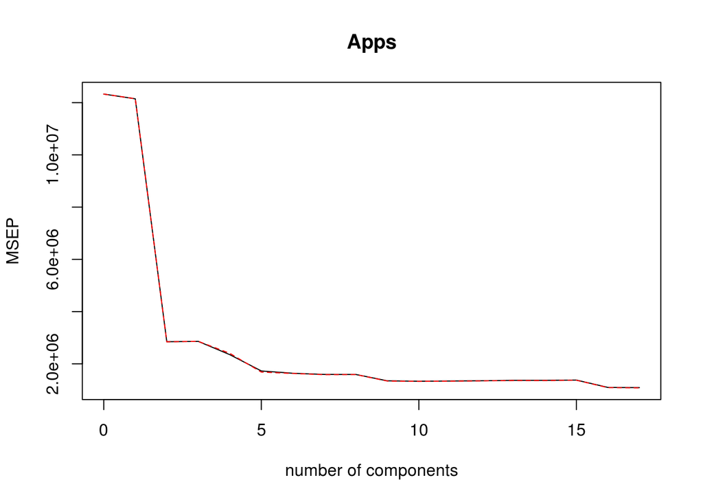

```r
validationplot(New.College.pcr, val.type = "MSEP")
```

```r
pcr.pred = predict(New.College.pcr, New.x.test, ncomp = 17)

mean((pcr.pred - New.y.test)^2)
```

```
## [1] 934377.2
```

## (New.f)

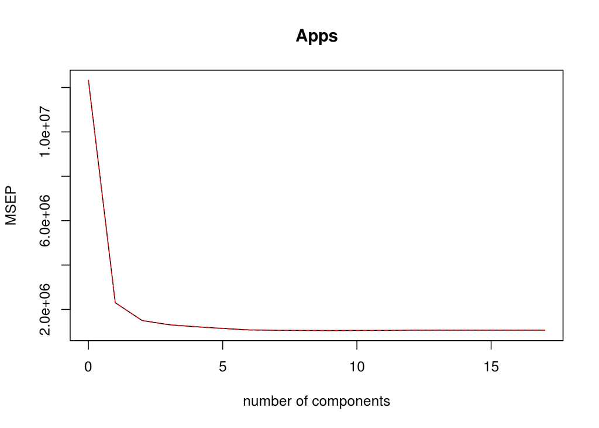

```r
New.College.pls = plsr(Apps ~ Private + Accept + Enroll + Top10perc + Top25perc + F.Undergrad + P.Undergrad + Outstate + Room.Board + Books + Personal + PhD + Terminal + S.F.Ratio + perc.alumni + Expend + Grad.Rate, data = New.College.training, scale = TRUE, validation = "CV")

validationplot(New.College.pls, val.type = "MSEP")
```

```r
pls.pred = predict(New.College.pls, New.x.test, ncomp = 12)

mean((pls.pred - New.y.test)^2)
```

```
## [1] 934164.7
```

## (New.g)

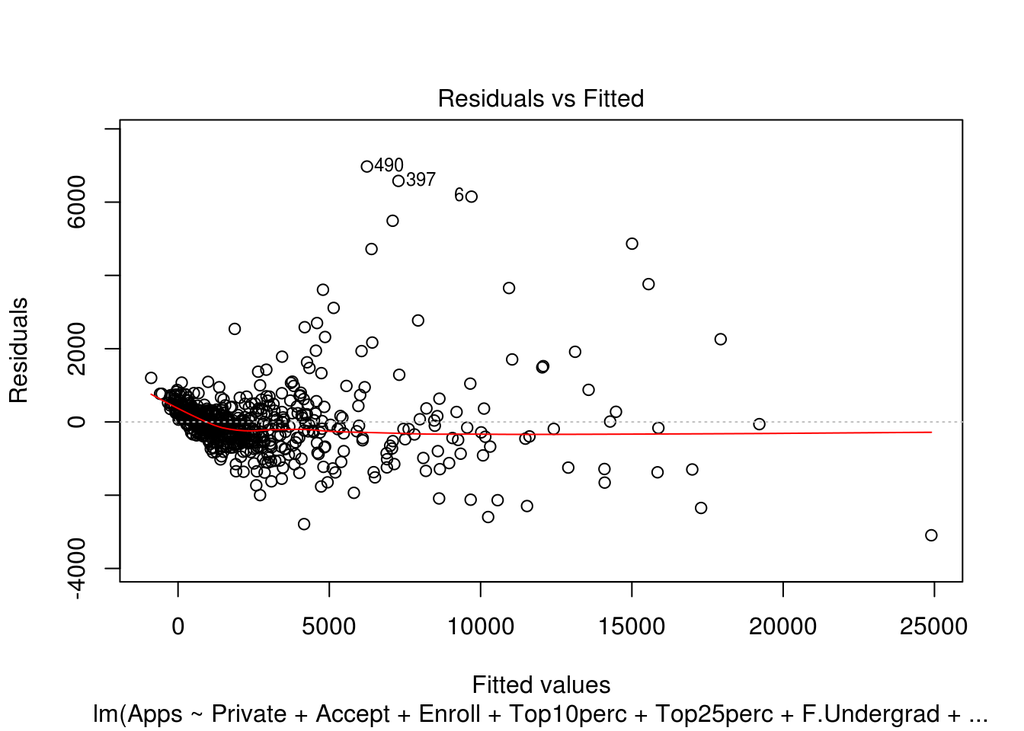

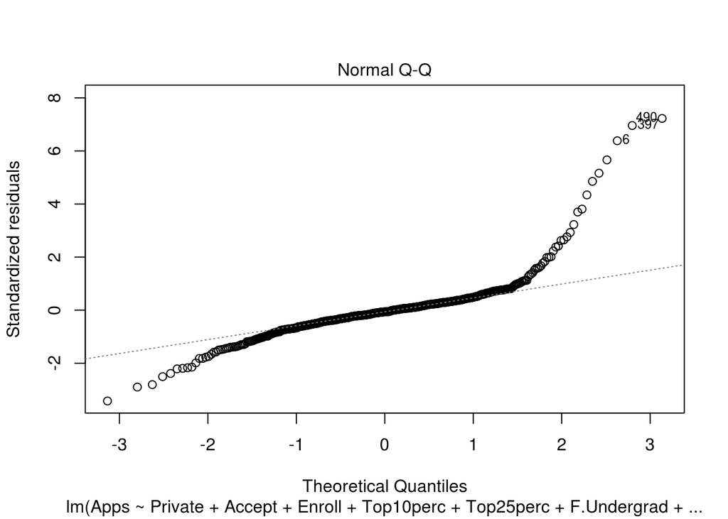

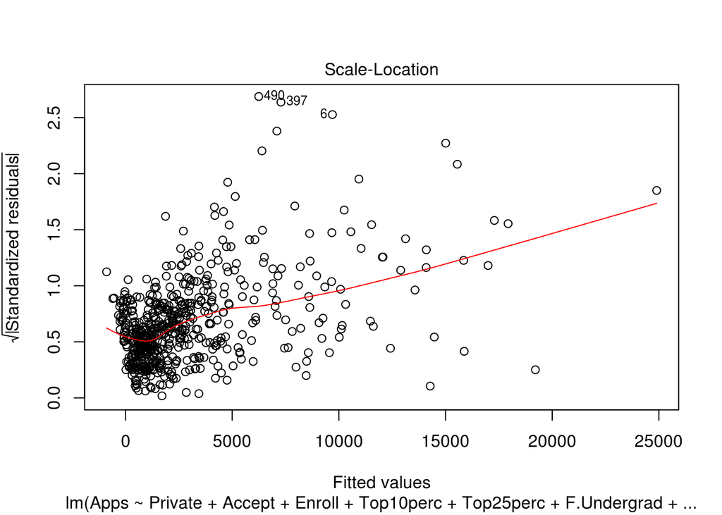

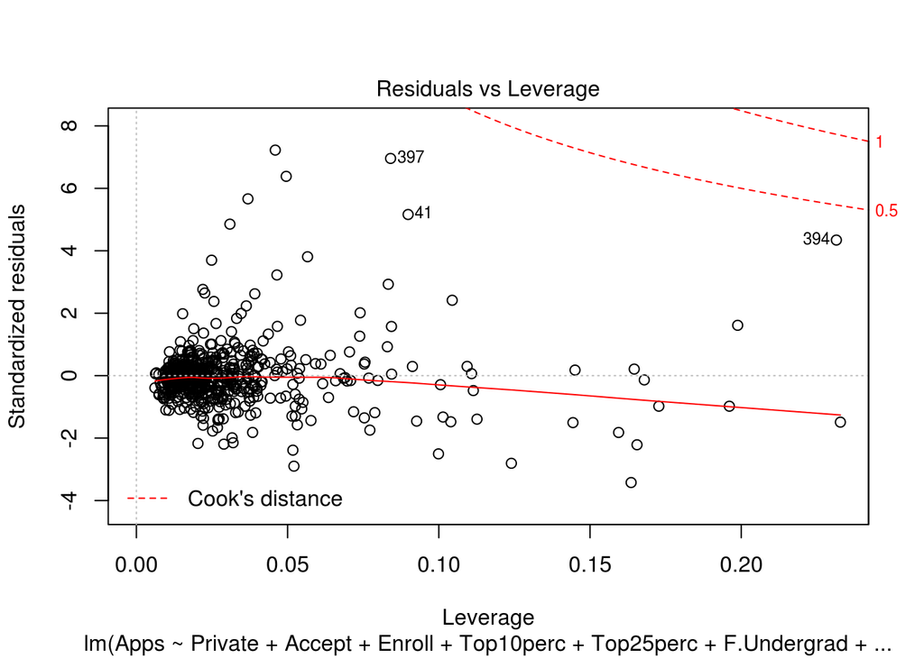

```r
plot(New.College.least.squares.training)
```

Somewhat as expected, we’re seeing a stark decrease in our test error across the board (except for in ridge regression I’m convinced I’ve done something wrong with that one, because it doesn’t exactly fall in line with the other complex models in my initial round of testing either. For the life of me, I can’t figure out what the issue is). That one college, our of nearly 800, was causing about 19% of our test error.

Sorry for getting a bit off topic with this one, it was all code and very little analysis so I got a bit antsy, plus that outlier was really getting under my skin.